# Exploring the BRFSS data

## Setup

### Load packages

```r
library(ggplot2)
library(dplyr)
```

### Load data

```r
load("brfss2013.RData")
```

## Part 1: Data

The data considered in this study are provided by the Centers for Disease Control and Prevention (CDC). They are part of the state-based Behavioral Risk Factor Surveillance System (BRFSS). This consists in a cross-state telephone survey aimed to address the health status of different households.

Each state is responsible, for their own interview choices and eventual stratification, however all the states are required to follow centralized guidelines. The survey is composed by mandatory modules, i.e., each state has to ask the mandatory questions and by optional modules. This  
level of freedom may introduce some bias, especially in the rate of questionnaires completed.

For this study I will focus only on data collected in 2013 and for people of 18 years or older.

The three following questions that are analyzed here, make use of the dataset where the questions were formulated independently. Therefore, this should be considerated like an “observation” and not like an “experiment”. As a consequence, while the conclusion can be generalized to the adult (age >18 years) population of the United States, they cannot be necessarily expanded to other continents and cannot definitely used to infer a direct casualty between the analyzed variables, can be at most outline cofounding variables.

Please refer to https://www.cdc.gov/brfss/data_documentation/index.htm for more info on the data, and to https://library.duke.edu/data/files/datasets/brfss_codebook.html##genhlth for a userfriendly version of the codebook.

## Part 2: Research questions

**Research question 1:**

The first research question I am interested in is whether or not a relation exists between physical activity and mental health, i.e., does physical activity help to improve mental health ?

**Research question 2:**

The second aspect that I want to address with this given dataset is whether or not an increased level of physical activity actually helps to reduce the occurrence of high cholesterol and high blood pressure, and if its effectiveness is related to the sex.

**Research question 3:**

Finally, is education level positively correlated with a person income ?

## Part 3: Exploratory data analysis

**Research question 1:**

The first research question that we want to address is if physical activity helps to improve mental health. During the interviews has been asked:

“Now thinking about your mental health, which includes stress, depression, and problems with emotions, for how many days during the past 30 days was your mental health not good?”

This is the information that we have, i.e., days of NOT GOOD mental health in the past 30 days.

From the codebook the relevant variables for this study are:

1. iyear: Interview Year, because we only want interviews on performed on 2013
2. menthlth: Number Of Days Mental Health Not Good, days of non good mental health
3. sex: Respondents Sex, because we want to investigate wether or not there is a difference between sexes
4. exerany2: Exercise In Past 30 Days, only select yes or no answers
5. exeroft1: How Many Times Walking, Running, Jogging, Or Swimming (Number starting with 1, i.e. 103 means 3 times a week, numbers starting with 2, i.e., 213 means 13 times a month).

Please note that this analysis does not include any information regarding income level and/or alcohol consumptions. These can affect the metal health of a person. As a consequence, this analysis may suffer of biases relative to states with lower income and or higher alcohol consumption rate, therefore it cannot be used to be prediction for a single state and/or other countries outside the US. Nevertheless, can show some preliminary results that can be worth investigating further.

As first step, lets select the variables relevant for this question, filter for year of interview, remove the “NA” values in mental health and in sex, and store the result in a new data-frame called mental.

```r
mental <- brfss2013 %>%
        select(iyear, menthlth, sex, exerany2,
               exeroft1, exerhmm1, exeroft2, exerhmm2) %>%
        filter(iyear == "2013", menthlth != "NA", sex !="NA", exerany2 !="NA" )
```

First lets have a look at the distribution of days of mental health

```r
table(mental$menthlth)
```

```
##
##      0      1      2      3      4      5      6      7      8      9
## 307521  14203  21916  12656   6211  15495   1726   5864   1152    175
##     10     11     12     13     14     15     16     17     18     19
##  11062     70    742     90   2312  10041    149     97    169     40
##     20     21     22     23     24     25     26     27     28     29
##   6139    463    106     59     81   2144     82    152    620    372
##     30
##  23338
```

We can see that the majority of people interviewed did not have any day of mental illness. In particular, 68% of the interviewed people that addressed the question on mental health said that they did not suffer of mental health during the past month (days of not good mental health equal to zero).

We can visualize this by using an histograms

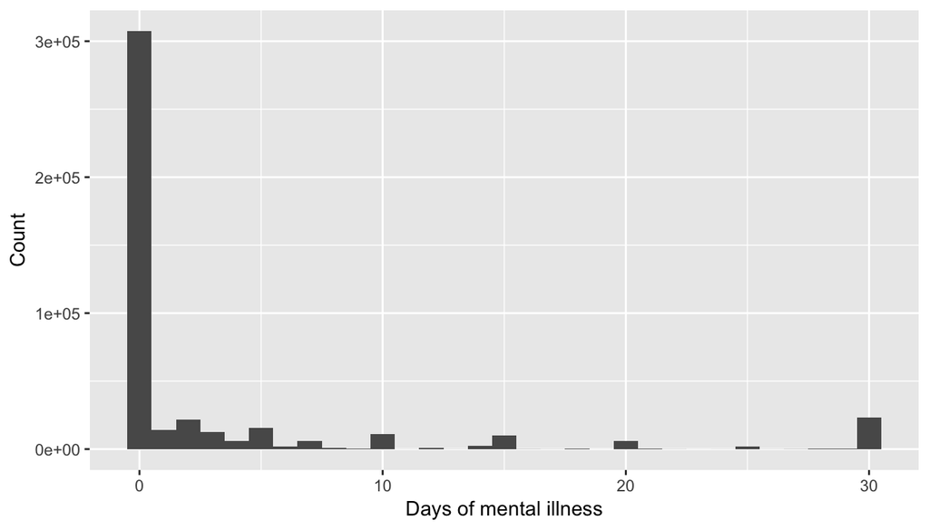

```r
ggplot(data=mental, aes(menthlth)) +
  geom_histogram(breaks=seq(-0.5,30.5, by=1)) + labs(x="Days of mental illness", y="Count")
```

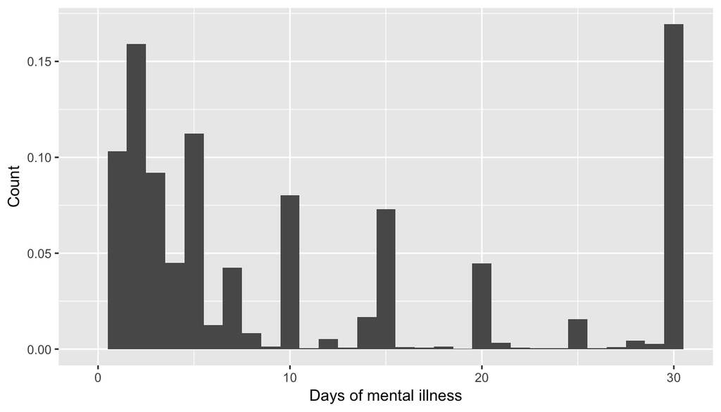

```r
mental <- mental %>% filter(menthlth != 0)
ggplot(data=mental, aes(menthlth)) +
  geom_histogram(breaks=seq(-0.5,30.5, by=1), aes(y = ..density..) ) + labs(x="Days of mental illness", y="Count")
```

The first thing that we notice is that about half of the people that suffered of mental suffered between 1 and 5 days, and about 20% suffered more than 25 days (see below) In particular:

```r
a <- as.data.frame( table(mental$menthlth))
sum(a$Freq[1:5])/sum(a$Freq)
```

```
## [1] 0.511748
```

```r
sum(a$Freq[25:30])/sum(a$Freq)
```

```
## [1] 0.1939213
```

We can see that there may be a trend in “rounding” the illness days, in fact we see picks at 5, 10, 15 20, and, in a smaller proportion at 25.

Now lets have a look if the trend changes between male and female. First let see how many female and males are there:

```r
table(mental$sex)
```

```
##
##   Male Female
##  46614  91112
```

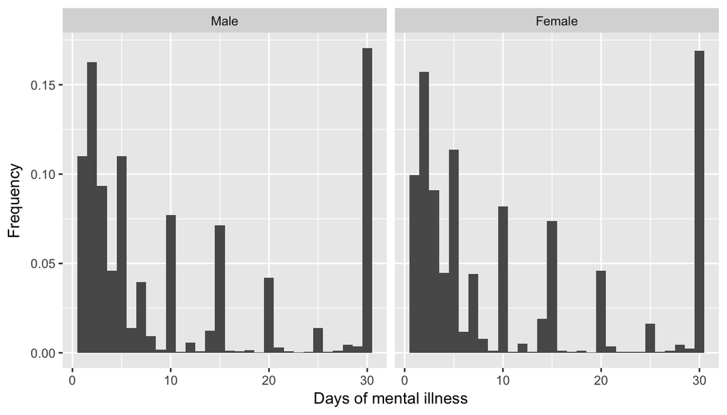

```r
ggplot(data=mental, aes(menthlth))  +
        geom_histogram(breaks=seq(0.5,30.5, by=1), aes(y = ..density..) ) +
        labs(x="Days of mental illness", y="Frequency") +
        facet_grid(.~sex)
```

The figure above suggests that the trends are independent by the sex.

Up to now we have looked at the distribution of mental ill days for all the people that answered the question, and we have also seen that the distribution seems to be independent from the sex.

As a first attempt to study the relation between physical activity and mental health, we are going to see if and how the distribution changes depending on whether or not the person does any physical activity. The amount of activity will be addressed afterwards.

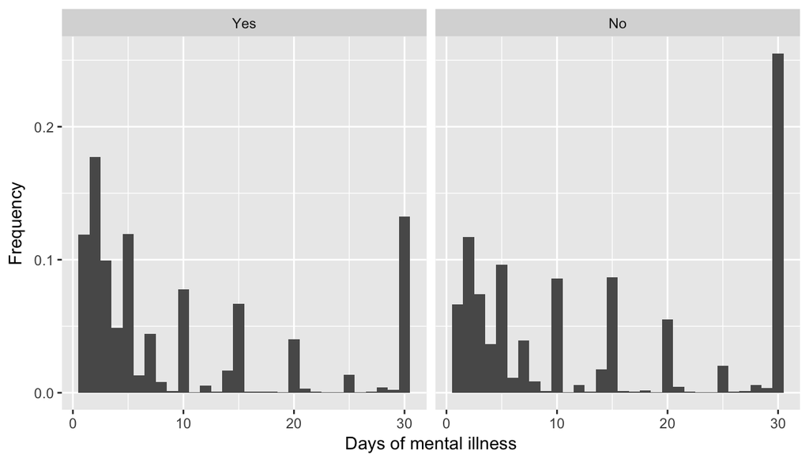

```r
ggplot(data=mental, aes(menthlth))  +
        geom_histogram(breaks=seq(0.5,30.5, by=1) , aes(y = ..density..))+
        labs(x="Days of mental illness", y="Frequency") +
        facet_grid(.~exerany2)
```

For the people that declared at least one day of illness, a comparison of the two panels shows that

1. The frequency of people that declare only up to 2 days of illness is higher for people that exercise than people that do not.
2. The frequency of people that declare 30 days of illness is lower for people that exercise than people that do not.

In particular if we look at the mean of ill days for people that exercised and that did not

```r
mental %>% group_by(exerany2) %>% summarise(mean_ill_days = mean(menthlth)) %>% rename(PhysicalActivity = exerany2)
```

```
## # A tibble: 2 x 2
##   PhysicalActivity mean_ill_days
##             <fctr>         <dbl>
## 1              Yes       9.60156
## 2               No      13.85253
```

We see that there seems to be a trend, however, the standard deviation is very high, suggesting a lot of variability.

```r
mental %>% group_by(exerany2) %>% summarise( st_dv_ill_days = sd(menthlth)) %>% rename(PhysicalActivity = exerany2)
```

```
## # A tibble: 2 x 2
##   PhysicalActivity st_dv_ill_days
##             <fctr>          <dbl>
## 1              Yes       9.818864
## 2               No      11.197358
```

To try to get a better idea, let’s first focus our attention only on people that declared to do physical activity.

```r
PhysActYes <- mental %>%
        filter(exerany2 == "Yes")

a <- as.data.frame(table(PhysActYes$menthlth))
```

First let’s see the % of people that suffered of mental illness at most 5 days:

```r
sum(a$Freq[1:5])/sum(a$Freq)
```

```
## [1] 0.5642905
```

And then the % of people that suffered of mental illness more than 25 days:

```r
sum(a$Freq[25:30])/sum(a$Freq)
```

```
## [1] 0.1536838
```

Now let’s focus on people that did not do any physical activity.

```r
 PhysActNo <- mental %>%
        filter(exerany2 == "No")

a <- as.data.frame(table(PhysActNo$menthlth))
```

First let’s see the % of people that suffered of mental illness at most 5 days:

```r
sum(a$Freq[1:5])/sum(a$Freq)
```

```
## [1] 0.3901735
```

And then the % of people that suffered of mental illness more than 25 days:

```r
sum(a$Freq[25:30])/sum(a$Freq)
```

```
## [1] 0.2870239
```

This comparison shows indeed that people that do physical activity tend to suffer less.

Now, for those who exercise let’s have a look at the relation between days of activity per week and mental health.

In order to do so, let’s first filter the dataset “mental” to include only the people that do physical activities and remove the “NA” from the time per week or month variable. While doing so we need to account for:

1. The following note in the codebook (page 38): “Notes: Section 12.01, EXERANY2, is coded 2, 7, 9, or Missing; or Section 12.02, EXRACT11 is coded 77, 99”.
2. Times are actually either per week or per month. To do so we use the information in the code book that tells us that times per weeks starts with 1 and times per months starts with 2.
3. After some trials I decided to limit the information to only people that gave the information in days per week, because the information in day per months seemed incongruent at times.
4. Make sure that there are no more than 6 days per week of exercises. I decided to remove the exactly 7 days a week exercises, because I felt that this is close to the code 77 and it seemed to have introduced a bias.

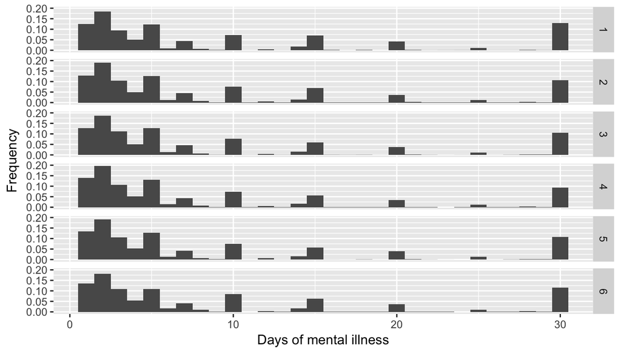

```r
# Just in case you don't want to limit to only times per week, but also
# use times per month (expressed in times per week)

# activity <- mental %>%
#          filter(exerany2 == "Yes", exeroft1 != "NA", exeroft1 != 77,
#                 exeroft1 != 99, exeroft1 != 177, exeroft1 != 199,
#                 exeroft1 != 277, exeroft1 != 299) %>%
#          mutate(timeXweek =round (ifelse(
#                  activity$exeroft1 >= 100 & activity$exeroft1 <=199,
#                  activity$exeroft1 - 100, (activity$exeroft1 - 200)/4)))  %>%
#          filter(timeXweek >= 1, timeXweek <= 6)

activity <- mental %>%
        filter(exerany2 == "Yes", exeroft1 != "NA",
               exeroft1 >= 100, exeroft1 <= 106) %>%
        mutate(timeXweek = exeroft1 - 100)

ggplot(data=activity, aes(menthlth))  +
        geom_histogram(breaks=seq(0.5,30.5, by=1) , aes(y = ..density..))+
        labs(x="Days of mental illness", y="Frequency") +
        facet_grid(timeXweek~.)
```

The Figure shows that not very clear and emerging conclusion seems to appear. Nevertheless, it seem that exercising 2 to 5 times a week helps reducing the numbers of cases that display 30 days of consecutive illness. In particular, 4 days a week seems optimal. However, due to the minor significance and to the large variance of the data, I would not feel confident in assuming that the a significant assumption between days of physical activity and reduced mental illness can be draw.

**Research question 2:**

The aim of this research question is to check if a relation exists between physical activity helps to reduce the occurrence of high cholesterol and high blood pressure, and if its effectiveness is related to the sex. Since we learned from the previous question that the number of days of physical activity is not extremely relevant we limit ourself only on yes/no physical activity in the past month. Also we only limit our analysis to people that had their cholesterol checked. This processes may include a bias because only people that are more health conscious and/or have more means are included in this analysis. For high blood pressure we do not include women that had it only during pregnancy (this is anyway a minor part of the sample and there would be inconsistency between the time information of the physical activity and of the pregnancy).

From the codebook the relevant variables for this study are:

1. iyear: Interview Year, because we only want interviews on performed on 2013
2. sex: Respondents Sex, because we want to investigate wether or not there is a difference between sexes
3. exerany2: Exercise In Past 30 Days, only select yes or no answers
4. bloodcho: Ever Had Blood Cholesterol Checked
5. toldhi2: Ever Told Blood Cholesterol High
6. bphigh4: Ever Told Blood Pressure High

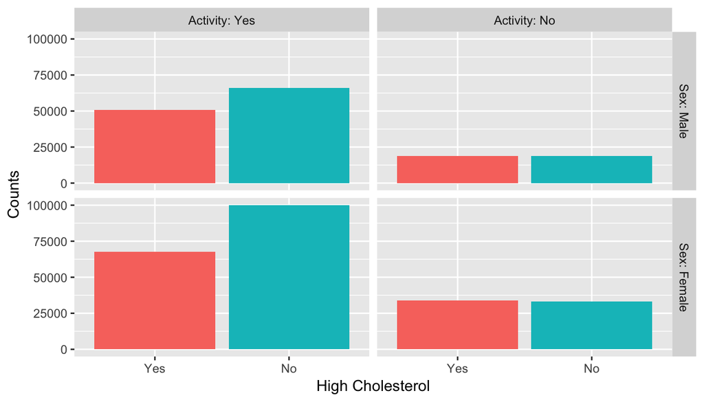

```r
chol <- brfss2013 %>%
        select(iyear, sex, exerany2,
               bloodcho, toldhi2) %>%
        filter(iyear == "2013", bloodcho == "Yes", sex !="NA", exerany2 !="NA", toldhi2 !="NA") %>%
        group_by(exerany2, toldhi2, sex) %>% summarise( Counts=n()) %>%
        rename(Activity = exerany2, high_chol = toldhi2, Sex =sex) # %>%
       # mutate(high_chol = as.numeric (high_chol))
chol <- as.data.frame(chol)

ggplot(data=chol, aes(x = high_chol, y = Counts, fill = high_chol))  +
        geom_bar(stat = "identity") +
        labs(x="High Cholesterol") +
        facet_grid(Sex~Activity, labeller = label_both) +
        guides(fill =FALSE)
```

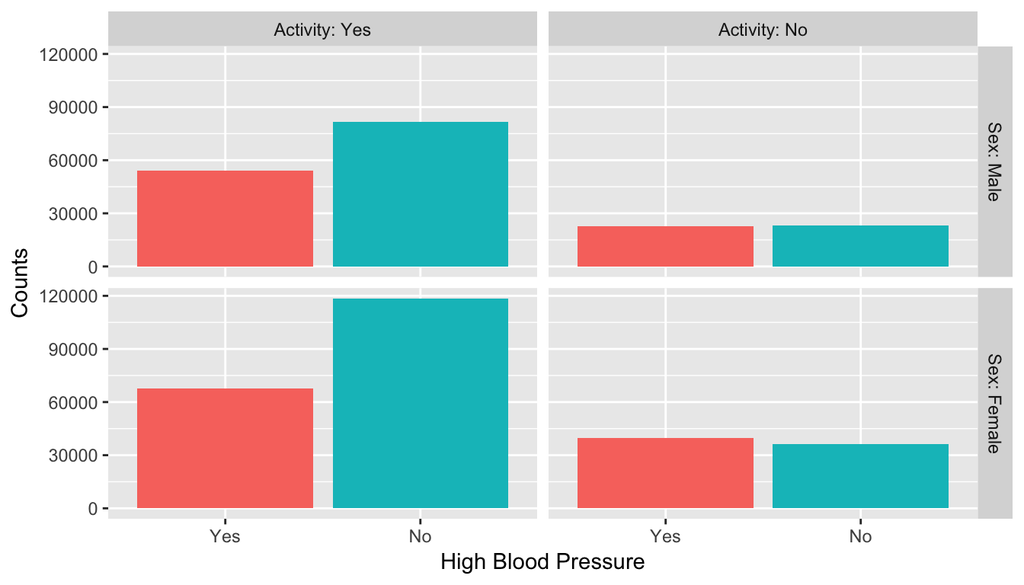

```r
press <- brfss2013 %>%
        select(iyear, sex, exerany2,
               bphigh4) %>%
        filter(iyear == "2013", sex !="NA", exerany2 !="NA", bphigh4!="NA",
               bphigh4!="Yes, but female told only during pregnancy",
               bphigh4!="Told borderline or pre-hypertensive") %>%
        group_by(exerany2, bphigh4, sex) %>% summarise( Counts=n()) %>%
        rename(Activity = exerany2, high_blood_pr = bphigh4, Sex = sex) # %>%
       # mutate(high_chol = as.numeric (high_chol))
press <- as.data.frame(press)

ggplot(data=press, aes(x = high_blood_pr, y = Counts, fill = high_blood_pr))  +
        geom_bar(stat = "identity") +
        labs(x="High Blood Pressure") +
        facet_grid(Sex~Activity, labeller = label_both)  +
        guides(fill =FALSE)
```

The two bar plots suggest that physical activity indeed helps to reduce both cholesterol and high blood pressure. It also seems to be more efficient for females than it is for men.

Finally, the two plots seems very similar and this may be due to the fact that people that have high cholesterol also have high blood pressure. In order to check this condition the following bar plot shows counts of people that have high cholesterol group for high blood pressure.

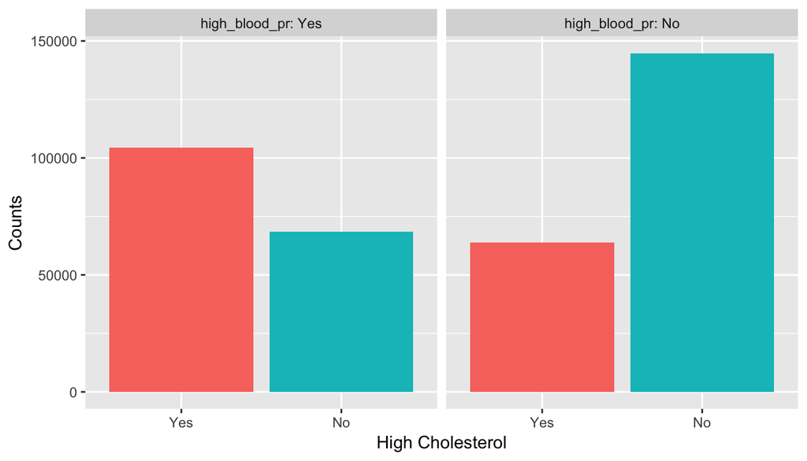

```r
corr <- brfss2013 %>%
        select(iyear, sex, exerany2,
               bloodcho, toldhi2, bphigh4) %>%
        filter(iyear == "2013", bloodcho == "Yes", sex !="NA", exerany2 !="NA",
               toldhi2 !="NA",  bphigh4!="NA",
               bphigh4!="Yes, but female told only during pregnancy",
               bphigh4!="Told borderline or pre-hypertensive") %>%
        group_by(toldhi2, bphigh4) %>% summarise( Counts=n()) %>%
        rename(high_chol = toldhi2, high_blood_pr = bphigh4) # %>%
       # mutate(high_chol = as.numeric (high_chol))
corr <- as.data.frame(corr)

ggplot(data=corr, aes(x = high_chol,  y = Counts, fill = high_chol))  +
        geom_bar(stat = "identity") +
        labs(x="High Cholesterol") +
        facet_grid(.~high_blood_pr, labeller = label_both) +
        guides(fill =FALSE)
```

Indeed, a correlation between the two seems to exist. However, it does not seems to definitive.

**Research question 3:**

The aim of this question is to see if a correlation between education level and income exists and if it depends on the sex.

From the codebook the relevant variables for this study are:

1. iyear: Interview Year, because we only want interviews on performed on 2013
2. sex: Respondents Sex, because we want to investigate wether or not there is a difference between sexes
3. income2: Income Level. 1: Less than $10,000, 2: Less than $15,000 ($10,000 to less than $15,000), 3: Less than $20,000 ($15,000 to less than $20,000), 4: Less than $25,000 ($20,000 to less than $25,000), 5: Less than $35,000 ($25,000 to less than $35,000), 6: Less than $50,000 ($35,000 to less than $50,000), 7: Less than $75,000 ($50,000 to less than $75,000), 8: $75,000 or more.
4. educa: Education Level. 1: Never attended school or only kindergarten, 2: Elementary school, 3: Some high school, 4: High school graduate, 5: some college, 6: College graduate.

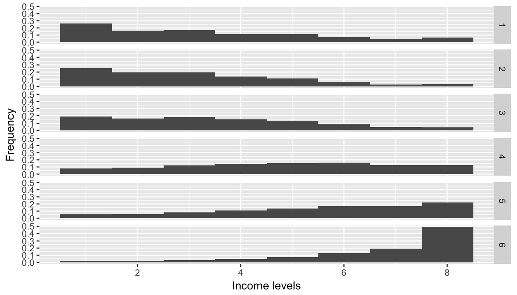

```r
inc_edu <- brfss2013 %>%
        select(iyear, sex, educa,
               income2) %>%
        filter(iyear == "2013",  sex !="NA", income2 !="NA",
               educa !="NA") %>%
        mutate(income = as.numeric(income2), Education = as.numeric(educa)) %>%
        rename(Sex = sex, education =educa)


        ggplot(data=inc_edu, aes(income))  +
        geom_histogram(breaks=seq(0.5,8.5, by=1),aes(y = ..density..))+
        labs(x="Income levels", y="Frequency") +
        facet_grid(Education~.)
```

```r
inc_edu %>% group_by(Education) %>% summarise(mean_income_level = mean(income), sd_income_level = sd(income) )
```

```
## # A tibble: 6 x 3
##   Education mean_income_level sd_income_level
##       <dbl>             <dbl>           <dbl>
## 1         1          3.365639        2.151699
## 2         2          3.057564        1.835249
## 3         3          3.534220        1.985904
## 4         4          4.808489        2.118770
## 5         5          5.505870        2.101864
## 6         6          6.733082        1.707893
```

We are now going to see how the above consideration is affected by the sex of the candidate. This is shown in the plot below.

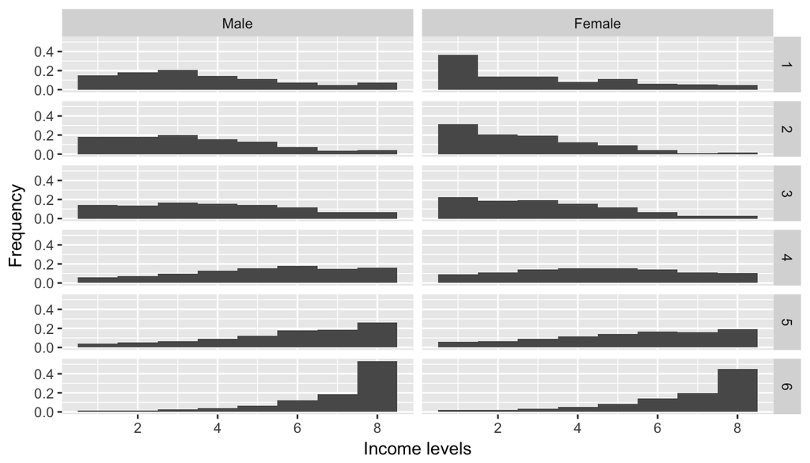

```r
        ggplot(data=inc_edu, aes(income))  +
        geom_histogram(breaks=seq(0.5,8.5, by=1),aes(y = ..density..))+
        labs(x="Income levels", y="Frequency") +
        facet_grid(Education~Sex)
```

As can be seen the overall trend is independent from the sex, i.e., higher education level leads to higher remuneration. However, for a given education level females tend to be paid less then men as evident from the different histograms and from the following table.

```r
inc_edu %>% group_by(Education, Sex) %>% summarise(mean_income_level = mean(income) )
```

```
## # A tibble: 12 x 3
## # Groups:   Education [?]
##    Education    Sex mean_income_level
##        <dbl> <fctr>             <dbl>
##  1         1   Male          3.677725
##  2         1 Female          3.094650
##  3         2   Male          3.435789
##  4         2 Female          2.726703
##  5         3   Male          3.970253
##  6         3 Female          3.210979
##  7         4   Male          5.180916
##  8         4 Female          4.532643
##  9         5   Male          5.791715
## 10         5 Female          5.319994
## 11         6   Male          6.871953
## 12         6 Female          6.623181
```

## Part 4: Conclusion

By using the the dataset provided by the Centers for Disease Control and Prevention (CDC), we have addressed the following questions:

1. Does physical activity help to reduce mental illness ?
2. Does physical activity help to reduce high cholesterol and high blood pressure ?
3. Is income level related to education level ?